# A Taxonomy of Research Gaps

Identifying and Defining the Seven Research Gaps

D. Anthony Miles

## How to find a puzzlement?

不会找困惑?救星来了！

Miles, D. A. (2017). A Taxonomy of Research Gaps: Identifying and Defining the Seven Research Gaps. In Doctoral Student Workshop: Finding Research Gaps-Research Methods and Strategies, Dallas, Texas.

One of the most prevailing issues in the craft of research is to develop a research agenda and build the research on the development of the research gap.

- Most research of any endeavor is attributed to the development of the research gap, which is a primary basis in the investigation of any problem, phenomenon or scientific question.
- Given this accepted tenet of engagement in research, surprising in the research fraternity, we do not train researchers on how to systematically identify research gaps as basis for the investigation.
- This is has continued to be a common problem with novice researchers. Unfailingly, very little theory and research has been developed on identifying research gaps as a basis for a line in inquiry.

The purpose of this **talk** is threefold.

- First, the proposed theoretical framework builds on the five-point theoretical model of Robinson, Saldanhea, and McKoy (2011) on research gaps.
- Second, this study builds on the six-point theoretical model of Müller-Bloch and Franz (2014) on research gaps.
- Lastly, the purpose of this research is to develop and propose a theoretical model that is an amalgamation of the two preceding models and re-conceptualizes the research gap concepts and their characteristics.

Thus, Miles proposes a seven-point theoretical model and discusses the characteristics of each research and the situation in which its application is warranted in the literature review.

The significance of this article is twofold.

- First, developing a theoretical model on research gaps.
- Second, building a solid taxonomy on the different characteristics of research gaps and establish a foundation.

The **implication** for researchers is that research gaps should be structured and characterized based on their functionality.

The idea of finding gaps in the research has been troubling for most researchers.

- For a considerable period of time, there were no formal or established frameworks for identifying or characterizing research gaps.
- Research gaps seem to be in the eye of the beholder. One researcher’s gap may be another searcher’s non-gap.
- A majority of this conflict with research gaps tends to tread on perception.

## Theoretical Foundation and Development

**Robinson, Saldanhea, and McKoy (2011)**

In their model, they identified and described five types of research gaps types: (a) Population, (b) Intervention, (c) Comparison, (d) Outcomes, and (e) Setting.

**Müller-Bloch and Kranz, (2014)**

- Their framework was based on Jacob’s (2011) theory on research problems.
  - Jacobs (2011) identified six kinds of research problems.
  - These problems parallel research gaps as discussed by Miller-Bloch and Kranz (2014).
- While research problems are not necessarily research gaps, they might be synonymous with research gaps:.

Their framework of research gaps consisted of six gaps: (a) Contradictory Evidence Gap; (b) Knowledge Void Gap; (c) Action-Knowledge Conflict Gap; (d) Methodological Gap; (e) Evaluation Void Gap; and (f) Theory Application Void Gap.

**Miles (2017)**

Miles (2017) proposed a new model built on the two previous models that consist of seven core research gaps renamed: (a) Evidence Gap; (b) Knowledge Gap; (c) Practical-Knowledge Conflict Gap; (d) Methodological Gap; (e) Empirical Gap; and (f) Theoretical Gap; (g) Population Gap.

- First, only using one construct from Robinson et al’s (2011) model.
- Second, re-conceptualized the model developed from Miller-Bloch and Kranz (2014) by simplifying the names of the constructs in their proposed framework.

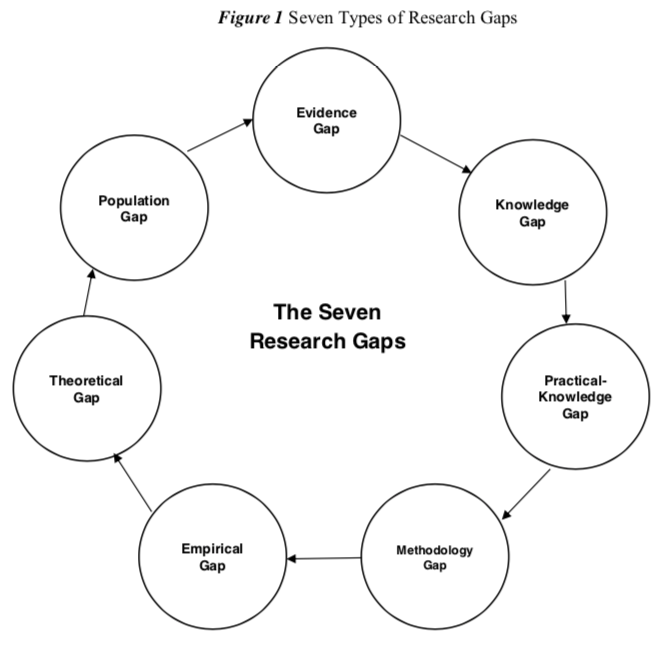

### Evidence Gap

An evidence gap occurs with a provocative exception arises if a new research finding contradicts widely accepted conclusions.

- This gap involves contradictions in the findings of the prior research.
- It occurs if results from studies allow for conclusions in their own right, but are contradictory when examined from a more abstract point of view.
- The identification of contradictory evidence starts with analyzing each research stream.
- Subsequently, the results from these analyses need to be synthesized in order to reveal contradictory evidence [Müller-Bloch & Kranz, 2014].

Evidence Gap (Contradictory Evidence Gap)

The researcher identified an apparent evidence gap in the prior research concerning**_**. Previous research has addressed several aspects of *__*: (1)**__**(cite two to three relevant articles), (2) **_** (cite two to three relevant articles), and (3) **_** (cite two to three relevant articles). However, the previous research has not address several contradictions in the findings concerning the prior research. The researcher has identified there is an evidence gap in the prior studies that are contradictory in the findings [Miles, 2017].

### Knowledge Gap

The knowledge gap is a common gap in the prior research. There are two settings where a knowledge gap (knowledge void) might occur.

- First, knowledge may not exist in the actual field to theories and literature from related research domains.
- Second, it might be the case that results of a study differs from what was expected [Müller-Bloch & Kranz, 2014].

Knowledge Gap (Knowledge Void Gap)

The researcher identified an apparent knowledge gap in the prior research concerning**_**. In addition, the prior research did not address the subject of **___**. This encompasses several unexplored dimensions that lately have attracted research attention in other disciplines (cite two to three relevant articles). The **___** should be explored further to provide an understanding as to why such is not the case with **__** [Miles, 2017].

### Practical-Knowledge Gap

This kind of gap tends to be a discrepancy that can motivate new research in this direction.

- A practical–knowledge (action-knowledge) conflict arises when the actual behavior of professionals is different from their advocated behavior.
- In this case, research could seek to determine the scope of the conflict and to uncover the reasons for its existence [Müller-Bloch & Kranz, 2014].

Practical Knowledge Gap (Action-Knowledge Conflict Gap)

There is appears to be a practical- knowledge gap in the prior research. There is a lack of rigorous research in the prior literature. Some of these unexplored*__* appear to be lacking in the practice of **__**field. The field of *__* is ripe for an investigation of practical focus research on *__*> Many of the prior studies focus on the theoretical aspects of the field of **__**. However, there are very few practical studies or action research in the field of **_**. This is an important and worthy of investigation in the context of *__*. An investigation of these issues is important because **__**. Furthermore, previous theoretical research has focused primarily on **___** and very little practical- research has been done on **__**field [Miles, 2017].

### Methodological Gap

A methodological gap is the type of gap that deals with the conflict that occurs due to the influence of methodology on research results.

- This gap addresses the conflicts with the research methods in the prior studies and offers a new line of research that is divergent from those research methods.
- It might be useful to vary research methods, especially if certain research topics have been mainly explored using a singular or common method [Müller- Bloch & Kranz, 2014].

The researcher identified a methodological gap in the prior research. There is a lack of *__*research designs in **___**.Based on the research we are trying implement as a research design, we found there is dearth in the prior research on**_** research designs. In this study we seek to establish a new inquiry on research designs with **__**. We seek to extend **___** the research by addressing the gaps with *__*in the research methodologies with *__* [Miles, 2017].

### Empirical Gap

An empirical gap is the type of gap that deals with gaps in the prior research.

- This conflict deals with the research findings or propositions need to be evaluated or empirically verified.

For example, the empirical gap often addresses conflicts that no study to date has directly attempted to evaluate a subject or topic from an empirical approach [Müller-Bloch & Kranz, 2014].

Empirical Gap (Evaluation Void Gap)

There is appears to be an empirical gap in the prior research. There is a lack of rigorous research in the prior literature. Some of these unexplored*__* appear to be important and worthy of investigation in the context of **_**. An empirical investigation of these issues is important because **___**. Furthermore, previous research has focused primarily on qualitative research concerning **___** . No study to date has directly attempted to empirically evaluate **_**. Very little empirical research has been done on **__** [Miles, 2017].

### Theoretical Gap

The theoretical gap is the type of gap that deals with the gaps in theory with the prior research.

For example, if one phenomenon is being explained through various theoretical models, similar to a methodological gap conflict, there might be a theoretical conflict.

- Researchers and scholars could examine whether one of those theories is superior in terms of the gap in the prior research.

Theoretical gaps are a common occurrence in examining prior research on a phenomenon [Müller-Bloch & Kranz, 2014].

Theoretical Gap (Theory Application Void Gap)

The researcher identified an apparent theoretical gap in the prior research concerning**_**. The theory on **__**is rather dated and the current studies bear the fruit of this theoretical gap. Some of the prior theory appear to be important and a foundation worthy of recognition. However, an investigation in terms of *__* and theoretical development is warranted. An investigation of these issues is important because *__* Furthermore, previous theoretical models need to embrace contemporary research in **__** and related fields to provide a stronger theoretical basis for projects. The previous theory tends to focus primarily on *__*. It does not encompass new paradigms in **__** [Miles, 2017].

### Population Gap

A population gap is a common gap recognized among researchers.

- There are always underserved populations that have been under-researched.

This gap is the type of research regarding the population that is not adequately represented or under-researched in the evidence base or prior research (e.g., gender, race/ethnicity, age and etic) [Robinson, et al, 2011].

Population Gap (Under-researched Sub-Groups Gap)

Based on the review of the prior research, there is a population gap. Some of these sub-populations have been unexplored and under- researched. The*__* appear to be important and worthy of investigation in the context of **__**. An investigation of this group is important because *__*. Furthermore, previous research has focused primarily on this population of **_**. Very little research has been done on **__**[Miles, 2017].

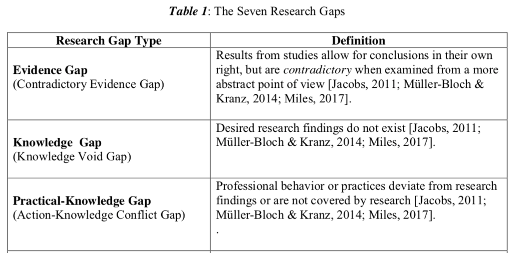

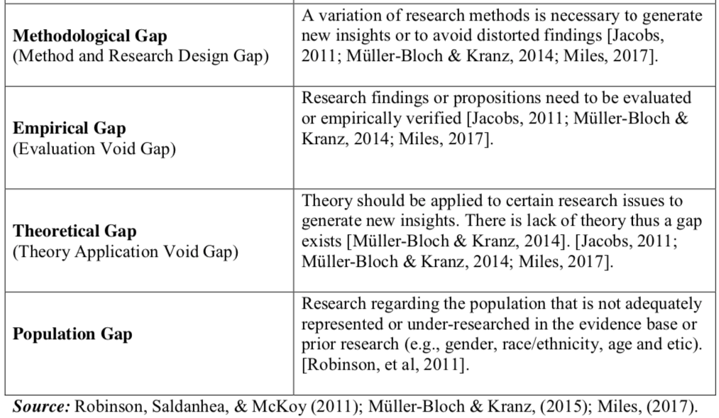

## Writing up the Research Gaps in a Research Proposal

To discuss the gaps in the prior research, you first must highlight some of the prior research in the literature that does not address the particular focus of the research. The contributions noted should relate back to gaps, inconsistencies, and controversies noted earlier. See Example 1:

Example 1: (Identify the research gap)

Previous research has addressed several aspects of *__*: (1) **__** (cite two to three relevant articles), (2) **_** (cite two to three relevant articles), and (3) **_** (cite two to three relevant articles) [Summers, 2001].

Then, researchers need to identify important gaps, inconsistencies, and/or controversies in the literature. This serves to establish the need for additional research in the topic area of interest. This task, like those that precede it, can be achieved in a concise manner. See Example 2 and Example 3. Consider the following sample template below:

Example 2: (Identify the research gap)

However, in addition, **___** encompasses several unexplored dimensions that lately have attracted research attention in other disciplines (cite two to three relevant articles) [Summers, 2001].

Example 3: (Identify the research gap)

Some of these unexplored*__* appear to be important and worthy of investigation in the context of **___**. An investigation of these issues is important because *__*. Furthermore, previous empirical research has focused primarily on **_** . Very little research has been done on **__** [Summers, 2001].

Finally, and most important, the researcher must provide a concise statement of the manuscript’s purposes, the contributions the manuscript makes to the literature. This Statement should follow logically from the text that identifies gaps, inconsistencies, and/or controversies in the literature. See Example 4 and Example 5:

Example 4:

In this study we seek to extend **___** by addressing the gaps in**_**. The study investigates the impact of four **___** (1) **__**, (2) **___**, (3)*__*, and (4) **_** . In addition, interrelationships among **__** are examined [Summers, 2001].

Example 5:

The researcher identified four major gaps in the prior research and literature.

First, the researcher identified an apparent theoretical gap in the prior research concerning **_**. The previous research has addressed several aspects of *__*: (1) **_**(cite two to three relevant articles), (2) **_** (cite two to three relevant articles), and (3) **_** (cite two to three relevant articles).

Second, based on the review of the prior research, there is a population gap. There is gap with**___**. This population segment has been under-researched in the prior literature. In addition, **_** encompasses several unexplored dimensions that lately have attracted research attention in other disciplines (cite two to three relevant articles).

Third, the researcher identified an apparent knowledge gap in the prior research concerning **_**. In addition, the prior research there is a conflict and contradiction in the findings of the prior studies that did not address the subject of **___**. Some of these unexplored **__** contradictions in the prior research appear to be important and worthy of investigation in the context of **_**. An investigation of these issues is important because **_**.

Lastly, the researcher identified an empirical gap in the prior research. There is a lack of rigorous research in the prior literature. The previous research has focused primarily on **__**. Very little research has been done on **__** to properly evaluation the problem. In this study we seek to provide a new inquiry on management practices with the federal government by addressing the gaps in *__*. The study investigates the impact of four: (1) **__**, (2)**_**, (3)*__*, and (4) **__**[Summers, 2001].

## References

- Jacobs, R. L. (2011). "Developing a Research Problem and Purpose Statement", in The Handbook of Scholarly Writing and Publishing, T. S. Rocco and T. Hatcher (eds.), San Francisco: Jossey-Bass, pp. 125–141.
- Miles, D.A. (2017). A Taxonomy of Research Gaps: Identifying and Defining the Seven Research Gaps, Doctoral Student Workshop: Finding Research Gaps - Research Methods and Strategies, Dallas, Texas, 2017.
- Müller-Bloch, C. & Kranz, J., (2014). A Framework for Rigorously Identifying Research Gaps in Qualitative Literature Reviews, The Thirty Sixth International Conference on Information Systems, Fort Worth 2015, pp. 1–19.
- Robinson, K., Saldanha, I. & McKoy, N.A. (2011). Development of A Framework for to Identify Research Gaps Systematic Reviews, Journal of Epidemiology, 64(1), pp. 1325-1330.
- Summers, J. (2011). Guidelines for Conducting Research and Publishing in Marketing: From Conceptualization Through the Review Process, Journal of the Academy of Marketing Science, 29(4), pp. 405-415.